# Colon and Lung Biomarker from TCGA project and MONOD Project

Shicheng Guo

June 1, 2017

## Preparation

### install R package: monod

library(devtools)

install_github(“Shicheng-Guo/newmonod”,force = TRUE)

library(“monod”)

### Data: genome-miner:

1. WGBS: **/media/Home_Raid1/shg047/NAS1/monod/mhl/0530/WGBS.getHaplo.mhl.mhbs.Guo.txt**
2. RRBS:**/media/Home_Raid1/shg047/NAS1/monod/mhl/0530/RRBS.getHaplo.mhl.mhbs.Guo.txt**
3. TCGA: **/media/NAS3_volume2/shg047/HM450/TCGA/Data/PancancerMethMatrix_March2016.RData**
4. TCGA: **/media/NAS3_volume2/shg047/HM450/TCGA/Data/PancancerMethSaminfoOct2016.txt**

We have notice that the markeres for colon and lung is not quite specific.

### Plan 1: Check the CpGs methylation levels in Colon and Lung Specific MHB/MHL markers

Read WGBS data:

```r
setwd("/media/Home_Raid1/shg047/NAS1/monod/mhl/0530")
data1<-read.table("/media/NAS1/shg047/monod/mhl/0530/WGBS.getHaplo.mhl.mhbs.Guo.txt",head=T,row.names=1,sep="\t",check.names = F)
data1<-rename2(data1)
sort(table(colnames(data1)))
```

```
##
##                     Adrenal                     Bladder
##                           1                           1
##                      Breast          fSpinal_Cord_cells
##                           1                           1
##                      HCT116                   intestine
##                           1                           1
##        Mobilized_CD34_cells                       Ovary
##                           1                           1
##                      PBRCAT                    Prostate
##                           1                           1
##  SRX381585_metastasis_colon SRX381611_metastasis_breast
##                           1                           1
##                     BrainAD                   Esophagus
##                           2                           2
##                      PCOADT                       PGBMT
##                           2                           2
##                      PKIRCT                    Placenta
##                           2                           2
##                      PLIHCT                      PPRADT
##                           2                           2
##                      Thymus                      Vessel
##                           2                           2
##                    Fat cell                   Intestine
##                           3                           3
##                       Liver                    Pancreas
##                           3                           3
##                        PLCT                      Spleen
##                           3                           3
##                      Kidney                        Lung
##                           4                           4
##                       Colon                     Stomach
##                           5                           5
##                       Brain                      Muscle
##                           6                           6
##                       Heart                         WBC
##                           7                           8
##                          H1
##                          10
```

```r
Data1<-data1[,grep("Brain|Colon|Intestine|Kidney|Liver|Lung|Pancreas|Spleen|Stomach|WBC",colnames(data1))]
colnames(Data1)<-unlist(lapply(colnames(Data1),function(x) unlist(strsplit(x,"[.]"))[1]))
table(colnames(Data1))
```

```
##
##     Brain   BrainAD     Colon Intestine    Kidney     Liver      Lung
##         6         2         5         3         4         3         4
##  Pancreas    Spleen   Stomach       WBC
##         3         3         5         8
```

Read RRBS data:

```r
data2<-read.table("/media/NAS1/shg047/monod/mhl/0530/RRBS.getHaplo.mhl.mhbs.Guo.txt",head=T,row.names=1,sep="\t",check.names = F)
sort(table(colnames(data2)))
```

```
##
##         CRC-P-10.2014.haploInfo.txt.mhbs
##                                        1
##         CRC-P-10.2016.haploInfo.txt.mhbs
##                                        1
##         CRC-P-11.2015.haploInfo.txt.mhbs
##                                        1
##          CRC-P-1.2014.haploInfo.txt.mhbs
##                                        1
##          CRC-P-1.2016.haploInfo.txt.mhbs
##                                        1
##         CRC-P-12.2015.haploInfo.txt.mhbs
##                                        1
##         CRC-P-13.2015.haploInfo.txt.mhbs
##                                        1
##         CRC-P-14.2015.haploInfo.txt.mhbs
##                                        1
##         CRC-P-15.2015.haploInfo.txt.mhbs
##                                        1
##         CRC-P-16.2015.haploInfo.txt.mhbs
##                                        1
##         CRC-P-17.2015.haploInfo.txt.mhbs
##                                        1
##         CRC-P-18.2015.haploInfo.txt.mhbs
##                                        1
##         CRC-P-19.2015.haploInfo.txt.mhbs
##                                        1
##         CRC-P-20.2015.haploInfo.txt.mhbs
##                                        1
##         CRC-P-21.2015.haploInfo.txt.mhbs
##                                        1
##          CRC-P-2.2014.haploInfo.txt.mhbs
##                                        1
##          CRC-P-2.2016.haploInfo.txt.mhbs
##                                        1
##         CRC-P-22.2015.haploInfo.txt.mhbs
##                                        1
##         CRC-P-23.2015.haploInfo.txt.mhbs
##                                        1
##         CRC-P-24.2015.haploInfo.txt.mhbs
```

[output cut: 368 more lines]

```
##                                        1
##           PC-P-9.2014.haploInfo.txt.mhbs
##                                        1
##           PC-P-9.2016.haploInfo.txt.mhbs
##                                        1
##           PC-T-1.2014.haploInfo.txt.mhbs
##                                        1
##           PC-T-2.2014.haploInfo.txt.mhbs
##                                        1
##           PC-T-4.2014.haploInfo.txt.mhbs
##                                        1
##           PC-T-6.2014.haploInfo.txt.mhbs
##                                        1
##           PC-T-7.2014.haploInfo.txt.mhbs
##                                        1
```

```r
Data2<-data2[,grep(".7P|X7.P|LC-P|.6P|X6.P|CCP|CRC-P|NC-P|NCP|NP",colnames(data2))]
```

Read TCGA 450K data:

```r
load("/media/NAS3_volume2/shg047/HM450/TCGA/Data/PancancerMethMatrix_March2016.RData")
see(data)
```

```
##            jhu.usc.edu_BLCA.HumanMethylation450.1.lvl.3.TCGA.BL.A0C8.01A.11D.A276.05.txt
## cg13869341                                                                         0.897
## cg14008030                                                                         0.741
## cg12045430                                                                         0.064
##            jhu.usc.edu_BLCA.HumanMethylation450.1.lvl.3.TCGA.BL.A0C8.01B.04D.A276.05.txt
## cg13869341                                                                         0.913
## cg14008030                                                                         0.708
## cg12045430                                                                         0.120
##            jhu.usc.edu_BLCA.HumanMethylation450.1.lvl.3.TCGA.BL.A13J.01A.11D.A276.05.txt
## cg13869341                                                                         0.886
## cg14008030                                                                         0.639
## cg12045430                                                                         0.096
```

```r
data450k<-data
```

Overlap between MHB and 450K array.

```r
cgoverlap<-bed2cg(cor2bed(rownames(Data1)))
```

```
## intersectBed -a /tmp/RtmpSdAA9Z/file28c5e3b22020b -b /tmp/RtmpSdAA9Z/file28c5e20b27fa2 -wao > /tmp/RtmpSdAA9Z/file28c5eab4e31a
```

```r
head(cgoverlap)
```

```
##       V1        V2        V3                        V4    V5        V6
## 2  chr10 100027957 100027993 chr10:100027957-100027993 chr10 100027958
## 3  chr10 100027957 100027993 chr10:100027957-100027993 chr10 100027962
## 10 chr10 100174875 100174962 chr10:100174875-100174962 chr10 100174935
## 12 chr10 100206398 100206511 chr10:100206398-100206511 chr10 100206399
## 14 chr10 100206732 100206860 chr10:100206732-100206860 chr10 100206752
## 15 chr10 100206732 100206860 chr10:100206732-100206860 chr10 100206770
##           V7         V8      V9     V10 V11 V12
## 2  100027959 cg24163616   LOXL4 N_Shore   I   1
## 3  100027963 cg09335911   LOXL4 N_Shore   I   1
## 10 100174936 cg22752023 PYROXD2    <NA>  II   1
## 12 100206400 cg13180809    HPS1    <NA>  II   1
## 14 100206753 cg06443542    HPS1    <NA>   I   1
## 15 100206771 cg04964571    HPS1    <NA>  II   1
```

Now, let’s check how many colon and lung specific MHL markers are hypermethylated.

```r
load("/media/Home_Raid1/shg047/NAS1/monod/mhl/0530/gsirlt.mhl.may30.RData")
head(gsirlt)
```

```
##                      region
## 1 chr10:100027918-100027945
## 2 chr10:100027957-100027993
## 3 chr10:100069336-100069469
## 4 chr10:100104146-100104361
## 5 chr10:100109482-100109518
## 6 chr10:100121047-100121067
##                                                                  group
## 1                                                                  WBC
## 2                                                            Intestine
## 3                                                                Brain
## 4 WBC,Brain,Colon,Intestine,Kidney,Liver,Lung,Pancreas,Spleen,Stomach,
## 5                                                       Liver,Stomach,
## 6       Pancreas,Colon,Intestine,Kidney,Liver,Lung,Spleen,Stomach,WBC,
##           GSI      refMax
## 1 0.003507908 0.002039703
## 2 0.015153070 0.006944444
## 3 0.063802998 0.039001200
## 4 0.356103012 0.884339001
## 5 0.439013631 0.451105734
## 6 0.586431336 0.817524046
##                                                                            refMean
## 1  0.00015,0.0017,0.00013,0.00027,0.00021,0.00028,0.00109,0.00063,0.00015,0.00204,
## 2                                     0.00104,0,0.00694,0,0,0.00167,0,0,0,0.00011,
## 3   0.039,0.01387,0.03216,0.00109,0.01044,0.00732,0.00104,0.00981,0.00274,0.01399,
## 4  0.80969,0.80983,0.59111,0.61698,0.6687,0.54837,0.55444,0.65648,0.85362,0.88434,
## 5 0.29409,0.00641,0.29064,0.20362,0.45111,0.10553,0.28433,0.00148,0.40084,0.00524,
## 6 0.14578,0.65723,0.30004,0.35417,0.47022,0.32366,0.81752,0.55332,0.40275,0.49032,
```

```r
gsirlt_colon<-gsirlt[which(unlist(lapply(gsirlt$group,function(x) length(grep("Colon",x))>0))),]
gsirlt_lung<-gsirlt[which(unlist(lapply(gsirlt$group,function(x) length(grep("Lung",x))>0))),]
```

All the CpG probes (450K) located in MHB regions are as the following:

```r
cpglist_colon<-bed2cg(cor2bed(gsirlt_colon$region))
```

```
## intersectBed -a /tmp/RtmpSdAA9Z/file28c5e762329b -b /tmp/RtmpSdAA9Z/file28c5e3024295d -wao > /tmp/RtmpSdAA9Z/file28c5e5a0a07db
```

```r
cpglist_lung<-bed2cg(cor2bed(gsirlt_lung$region))
```

```
## intersectBed -a /tmp/RtmpSdAA9Z/file28c5e1a646062 -b /tmp/RtmpSdAA9Z/file28c5e19110bea -wao > /tmp/RtmpSdAA9Z/file28c5e6f8f2fbb
```

```r
dim(cpglist_colon)
```

```
## [1] 12034    12
```

```r
dim(cpglist_lung)
```

```
## [1] 9504   12
```

Okay, now check the methylation leveles for these CpGs in the corresponding cancer and normal samples. First trim and rename 450K dataset and be clear the sampleid, sampletype and colon type.

```r
tcgacancertype<-function(filename){
cancertype<-unlist(lapply(filename,function(x) unlist(strsplit(x,"_|.Human"))[2]))
return(cancertype)
}

tcgasampleid<-function(filename){
  id<-as.array(str_extract(filename,"TCGA.[0-9|a-z|A-Z]*.[0-9|a-z|A-Z]*.[0-9]*"))
  id<-gsub("[.]","-",id)
  return(id)
}

tcgasampletype<-function(filename){
id<-as.array(str_extract(filename,"TCGA.[0-9|a-z|A-Z]*.[0-9|a-z|A-Z]*.[0-9]*"))
sampletype<- substr(id,14,15)
return(sampletype)
}

cancertype<-tcgacancertype(colnames(data450k))
sampletype<-tcgasampletype(colnames(data450k))
sampleid<-tcgasampleid(colnames(data450k))
table(cancertype)
```

```
## cancertype
## BLCA CESC COAD DLBC ESCA  GBM HNSC KICH KIRC KIRP  LGG LIHC LUAD MESO   OV
##  436  311  347   48  201  142  578   66  482  320  518  427  501   87   10
## PRAD READ SARC THCA UCEC
##  552  105  265  563  481
```

```r
table(sampletype)
```

```
## sampletype
##   01   11
## 5857  583
```

```r
print(paste("Note: 01 is cancer while 11 is normal"))
```

```
## [1] "Note: 01 is cancer while 11 is normal"
```

```r
head(sampleid)
```

```
## [1] "TCGA-BL-A0C8-01" "TCGA-BL-A0C8-01" "TCGA-BL-A13J-01" "TCGA-BL-A13J-01"
## [5] "TCGA-BL-A13J-11" "TCGA-BT-A0S7-01"
```

1. For colon cancer, to check the methylation status of the CpG probes located in MHB.

```r
tcga_colon1<-data450k[match(cpglist_colon$V8,rownames(data450k)),cancertype=="COAD"]
tcga_colon2<-data450k[match(cpglist_colon$V8,rownames(data450k)),cancertype=="COAD" & sampletype=="01"]
tcga_colon3<-data450k[match(cpglist_colon$V8,rownames(data450k)),cancertype=="COAD" & sampletype=="11"]
dim(tcga_colon1)
```

```
## [1] 12034   347
```

```r
dim(tcga_colon2)
```

```
## [1] 12034   308
```

```r
dim(tcga_colon3)
```

```
## [1] 12034    39
```

```r
see(tcga_colon1)
```

```
##            jhu.usc.edu_COAD.HumanMethylation450.1.lvl.3.TCGA.A6.2671.01A.01D.1407.05.txt
## cg14280330                                                                         0.387
## cg26075184                                                                         0.212
## cg08287265                                                                         0.092
##            jhu.usc.edu_COAD.HumanMethylation450.1.lvl.3.TCGA.A6.2671.11A.01D.1551.05.txt
## cg14280330                                                                         0.776
## cg26075184                                                                         0.218
## cg08287265                                                                         0.300
##            jhu.usc.edu_COAD.HumanMethylation450.1.lvl.3.TCGA.A6.2679.01A.02D.1407.05.txt
## cg14280330                                                                         0.385
## cg26075184                                                                         0.244
## cg08287265                                                                         0.726
```

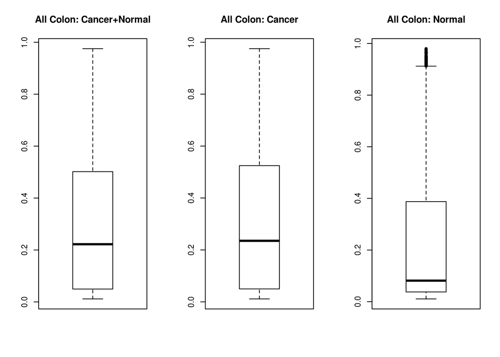

```r
par(mfrow=c(1,3))

cc1<-apply(tcga_colon1,1,function(x) mean(x,na.rm=T))
cc2<-apply(tcga_colon2,1,function(x) mean(x,na.rm=T))
cc3<-apply(tcga_colon3,1,function(x) mean(x,na.rm=T))
boxplot(na.omit(unlist(cc1)),main="All Colon: Cancer+Normal")
boxplot(na.omit(unlist(cc2)),main="All Colon: Cancer")
boxplot(na.omit(unlist(cc3)),main="All Colon: Normal")
```

```r
sum(na.omit(unlist(cc1>0.3)))/nrow(tcga_colon1)
```

```
## [1] 0.427871
```

```r
sum(na.omit(unlist(cc2>0.3)))/nrow(tcga_colon2)
```

```
## [1] 0.4400864
```

```r
sum(na.omit(unlist(cc3>0.3)))/nrow(tcga_colon3)
```

```
## [1] 0.2728104
```

Okay, we can notice that only 43% WGBS GSI markers have beta>0.3 in 450K dataset (cancer+normal). What’s worse, only 27% WGBS GSI markers have beta>0.3 in 450K dataset (only in normal).

2. For lung cancer, to check the methylation status of the CpG probes located in MHB.

```r
tcga_lung1<-data450k[,cancertype=="LUAD"|cancertype=="LUSC"]                       # for all lung
tcga_lung2<-data450k[,(cancertype=="LUAD"|cancertype=="LUSC") & sampletype=="01"]  # for lung cancer
tcga_lung3<-data450k[,(cancertype=="LUAD"|cancertype=="LUSC") & sampletype=="11"]  # for lung normal

dim(tcga_lung1)
```

```
## [1] 485512    501
```

```r
dim(tcga_lung2)
```

```
## [1] 485512    469
```

```r
dim(tcga_lung3)
```

```
## [1] 485512     32
```

```r
see(tcga_lung1)
```

```
##            jhu.usc.edu_LUAD.HumanMethylation450.1.lvl.3.TCGA.44.2655.11A.01D.1551.05.txt
## cg13869341                                                                         0.883
## cg14008030                                                                         0.706
## cg12045430                                                                         0.032
##            jhu.usc.edu_LUAD.HumanMethylation450.1.lvl.3.TCGA.44.2656.01A.02D.A276.05.txt
## cg13869341                                                                         0.875
## cg14008030                                                                         0.655
## cg12045430                                                                         0.112
##            jhu.usc.edu_LUAD.HumanMethylation450.1.lvl.3.TCGA.44.2656.01B.06D.A276.05.txt
## cg13869341                                                                         0.899
## cg14008030                                                                         0.623
## cg12045430                                                                         0.078
```

[figure not shown]

```r
par(mfrow=c(1,3))
lc1<-apply(tcga_lung1,1,function(x) mean(x,na.rm=T))
lc2<-apply(tcga_lung2,1,function(x) mean(x,na.rm=T))
lc3<-apply(tcga_lung3,1,function(x) mean(x,na.rm=T))
boxplot(na.omit(unlist(lc1)),main="All Colon: Cancer+Normal")
boxplot(na.omit(unlist(lc2)),main="All Colon: Cancer")
boxplot(na.omit(unlist(lc3)),main="All Colon: Normal")
```

```r
sum(na.omit(unlist(cc1>0.3)))/nrow(tcga_lung1)
```

```
## [1] 0.0106053
```

```r
sum(na.omit(unlist(cc2>0.3)))/nrow(tcga_lung2)
```

```
## [1] 0.01090807
```

```r
sum(na.omit(unlist(cc3>0.3)))/nrow(tcga_lung3)
```

```
## [1] 0.006761934
```

3. Can we have higher plasma mapping ratio with validate biomarkers. Now update the biomarkers. remove the colon and lung markers which are < 0.3 in TCGA dataset.

```r
colonremove<-cgoverlap[na.omit(match(names(which(cc1<0.3)),cgoverlap$V8)),]$V4
lungremove<-cgoverlap[na.omit(match(names(which(lc1<0.3)),cgoverlap$V8)),]$V4
remove<-unique(c(match(colonremove,gsirlt[,1]),match(lungremove,gsirlt[,1])))
Gsirlt<-gsirlt[-remove,]
```

4, Do the tissue-of-origin prediction again.

```r
gsirlt1<-subset(Gsirlt,refMax>0.3 & GSI>0.65)  # refMax=c(0.3-0.6), GSI=c(0.5-0.7)
gsirlt1$group<-as.character(gsirlt1$group)
bio<-gsi2bio(gsirlt1)

# predict solid tissue(normals)
rlt1<-prediction1(Data1,bio,tt=0.6)
rlt1$prediction
```

```
##      Kidney      Kidney         WBC       Colon     BrainAD     BrainAD
##    "Kidney"    "Kidney"       "WBC"     "Colon"     "Brain"     "Brain"
##       Brain       Brain       Brain       Colon       Brain       Liver
##     "Brain"     "Brain"     "Brain"     "Colon"     "Brain"     "Liver"
##        Lung    Pancreas     Stomach       Colon       Liver       Brain
##      "Lung"  "Pancreas"   "Stomach"     "Colon"     "Liver"     "Brain"
##       Brain        Lung         WBC     Stomach        Lung   Intestine
##     "Brain"      "Lung"       "WBC"   "Stomach"      "Lung" "Intestine"
##       Colon      Spleen      Kidney     Stomach        Lung    Pancreas
##     "Colon"    "Spleen"    "Kidney"   "Stomach"      "Lung"  "Pancreas"
##   Intestine      Spleen      Kidney     Stomach    Pancreas   Intestine
## "Intestine"    "Spleen"    "Kidney"   "Stomach"  "Pancreas" "Intestine"
##       Colon      Spleen       Liver         WBC         WBC         WBC
## "Intestine"    "Spleen"     "Liver"       "WBC"       "WBC"       "WBC"
##         WBC     Stomach         WBC         WBC
##       "WBC"   "Stomach"       "WBC"       "WBC"
```

```r
sum(rlt1$prediction==names(rlt1$prediction))/length(rlt1$prediction)
```

```
## [1] 0.9347826
```

It’s cool. solid normal tissue mapping accuray is still 93.47826%, only one Colon was predicted to “Intestine”. Go on, to check the plasma data prediction.

```r
np<-Data2[,grep("NC-P|NCP|NP",colnames(Data2))]
train<-sample(1:75,45)
ncp<-np[,train]
nncp<-np[,(1:75)[-train]]
ccp<-Data2[,unique(grep(".6P|X6.P|CCP|CRC-P",colnames(Data2)))]
lcp<-Data2[,unique(grep(".7P|X7.P|LC-P",colnames(Data2)))]

rlt1<-ZscorePredictionPlasma1(nncp,ncp,bio,tt=0.001)    # tt is threshold to binary the MHL matrix, lcp: colon cancer plasma, ncp: normal plasma trainning dataset
rlt2<-ZscorePredictionPlasma1(ccp,ncp,bio,tt=0.001)     # tt is threshold to binary the MHL matrix, ccp: colon cancer plasma, ncp: normal plasma trainning dataset
rlt3<-ZscorePredictionPlasma1(lcp,ncp,bio,tt=0.001)     # tt is threshold to binary the MHL matrix, ccp: colon cancer plasma, ncp: normal plasma trainning dataset
rlt2$testcounts
```

```
##           CRC-P-1.2014.haploInfo.txt.mhbs CRC-P-1.2016.haploInfo.txt.mhbs
## Brain                                 230                              37
## Colon                                 626                             178
## Intestine                             346                             104
## Kidney                                250                              55
## Liver                                 286                              61
## Lung                                  531                             141
## Pancreas                              220                              56
## Spleen                                841                             245
## Stomach                               166                              44
## WBC                                   860                             249
##           CRC-P-10.2014.haploInfo.txt.mhbs
## Brain                                  199
## Colon                                  602
## Intestine                              321
## Kidney                                 239
## Liver                                  266
## Lung                                   490
## Pancreas                               206
## Spleen                                 803
## Stomach                                152
## WBC                                    814
##           CRC-P-10.2016.haploInfo.txt.mhbs
## Brain                                  250
## Colon                                  578
## Intestine                              308
## Kidney                                 267
## Liver                                  270
## Lung                                   492
## Pancreas                               199
## Spleen                                 789
## Stomach                                147
## WBC                                    808
##           CRC-P-11.2015.haploInfo.txt.mhbs
## Brain                                  181
## Colon                                  508
## Intestine                              272
## Kidney                                 177
## Liver                                  207
## Lung                                   423
```

[output cut: 264 more lines]

```
## Pancreas                              203                             156
## Spleen                                773                             710
## Stomach                               156                             139
## WBC                                   798                             727
##           CRC-P-9.2014.haploInfo.txt.mhbs CRC-P-9.2016.haploInfo.txt.mhbs
## Brain                                 249                             224
## Colon                                 646                             517
## Intestine                             356                             280
## Kidney                                283                             218
## Liver                                 314                             239
## Lung                                  552                             455
## Pancreas                              246                             166
## Spleen                                885                             709
## Stomach                               178                             147
## WBC                                   902                             720
```

```r
rlt2$nprscore[1:10,1:3]
```

```
##           NC-P-6.2014.haploInfo.txt.mhbs NC-P-63.2016.haploInfo.txt.mhbs
## Brain                        -2.60325517                       0.2171722
## Colon                        -0.26113178                       0.3853964
## Intestine                     1.05904840                      -0.2244449
## Kidney                       -1.46948367                       0.2937798
## Liver                         3.76714180                      -0.3402512
## Lung                         -2.09903423                       0.3550990
## Pancreas                      1.48477345                      -0.2099401
## Spleen                        0.60388282                       0.1775941
## Stomach                       0.02512162                      -0.2511871
## WBC                          -0.28819580                      -0.2984751
##           NC-P-56.2016.haploInfo.txt.mhbs
## Brain                           0.1873122
## Colon                           0.3148740
## Intestine                      -0.1282821
## Kidney                          0.5358912
## Liver                           0.3833493
## Lung                            0.2182479
## Pancreas                       -0.2617829
## Spleen                         -0.6819682
## Stomach                        -1.2849220
## WBC                             0.4998226
```

```r
rlt2$ccprscore[1:10,1:3]
```

```
##           CRC-P-1.2014.haploInfo.txt.mhbs CRC-P-1.2016.haploInfo.txt.mhbs
## Brain                         -0.16717547                      -1.6928243
## Colon                         -0.30071083                       0.5506983
## Intestine                      0.60465940                       3.4891892
## Kidney                         0.26686702                      -0.7373917
## Liver                         -0.07840931                      -0.8214800
## Lung                           0.95297725                      -1.2309004
## Pancreas                      -0.22386356                       1.1456344
## Spleen                        -1.14675537                      -1.7556775
## Stomach                       -0.25187356                       1.5289163
## WBC                           -0.89176344                      -2.4143149
##           CRC-P-10.2014.haploInfo.txt.mhbs
## Brain                          -0.68143498
## Colon                           0.84422749
## Intestine                       0.25201779
## Kidney                          0.76833307
## Liver                           0.07353434
## Lung                            0.01469034
## Pancreas                        0.03466678
## Spleen                         -0.02610123
## Stomach                        -0.41425336
## WBC                            -1.21522347
```

heatmap to show the number, Z-score and P-values normal plasma

```r
#label: unnamed-chunk-9
#Quitting from lines 195-198 (monod-mhb-TCGA-biomarkeresearch.Rmd)
#Error in plot.new() : figure margins too large
pdf("heatmap-np.pdf")
HeatMap(rlt1$testcounts)
HeatMap(rlt1$ccprscore)
HeatMap(-log(pnorm(-abs(rlt1$ccprscore)),10))
dev.off()
```

heatmap to show the number, Z-score and P-values for colon cancer plasma

```r
pdf("heatmap-ccp.pdf")
HeatMap(rlt2$testcounts)
HeatMap(rlt2$ccprscore)
HeatMap(-log(pnorm(-abs(rlt2$ccprscore)),10))
dev.off()
```

heatmap to show the number, Z-score and P-values for lung cancer plasma

```r
pdf("heatmap-lcp.pdf")
HeatMap(rlt3$testcounts)
HeatMap(rlt3$ccprscore)
HeatMap(-log(pnorm(-abs(rlt3$ccprscore)),10))
dev.off()
```

```r
pvalue1<-pnorm(-abs(rlt1$ccprscore))
pvalue2<-pnorm(-abs(rlt2$ccprscore))
pvalue3<-pnorm(-abs(rlt3$ccprscore))
prin1<-sum(unlist(apply(pvalue1,2,function(x) rownames(rlt1$score)[which(x<0.01)]))=="WBC")
prin2<-sum(unlist(apply(pvalue2,2,function(x) rownames(rlt1$score)[which(x<0.01)]))=="Colon")
prin3<-sum(unlist(apply(pvalue3,2,function(x) rownames(rlt2$score)[which(x<0.01)]))=="Lung")
prin1
```

```
## [1] 4
```

```r
prin2
```

```
## [1] 1
```

optimization to check is there any acceptable result

```r
for(i in seq(0,0.3,by=0.01)){
rlt1<-ZscorePredictionPlasma1(nncp,ncp,bio,tt=i)    # tt is threshold to binary the MHL matrix, lcp: colon cancer plasma, ncp: normal plasma
rlt2<-ZscorePredictionPlasma1(ccp,ncp,bio,tt=i)     # tt is threshold to binary the MHL matrix, ccp: colon cancer plasma, ncp: normal plasma
rlt3<-ZscorePredictionPlasma1(lcp,ncp,bio,tt=i)     # tt is threshold to binary the MHL matrix, ccp: colon cancer plasma, ncp: normal plasma
pvalue1<-pnorm(-abs(rlt1$ccprscore))
pvalue2<-pnorm(-abs(rlt2$ccprscore))
pvalue3<-pnorm(-abs(rlt3$ccprscore))
prin1<-sum(unlist(apply(pvalue1,2,function(x) length(grep("WBC",rownames(rlt1$score)[which(x<0.01)]))>1)))
prin2<-sum(unlist(apply(pvalue2,2,function(x) length(grep("Colon",rownames(rlt2$score)[which(x<0.01)]))>1)))
prin3<-sum(unlist(apply(pvalue3,2,function(x) length(grep("Lung",rownames(rlt3$score)[which(x<0.01)]))>1)))
print(c(i,prin1,prin2,prin3))
}
```

```
## [1] 0 0 0 0
## [1] 0.01 0.00 0.00 0.00
## [1] 0.02 0.00 0.00 0.00
## [1] 0.03 0.00 0.00 0.00
## [1] 0.04 0.00 0.00 0.00
## [1] 0.05 0.00 0.00 0.00
## [1] 0.06 0.00 0.00 0.00
## [1] 0.07 0.00 0.00 0.00
## [1] 0.08 0.00 0.00 0.00
## [1] 0.09 0.00 0.00 0.00
## [1] 0.1 0.0 0.0 0.0
## [1] 0.11 0.00 0.00 0.00
## [1] 0.12 0.00 0.00 0.00
## [1] 0.13 0.00 0.00 0.00
## [1] 0.14 0.00 0.00 0.00
```

[output cut: 16 more lines]

### Plan 2: Identify lung cancer and colon specific markers with 450K array and then apply these markers/regions as colon and lung specific marker to do plasma prediction??